# FINALPROJ

Vinh Ton

2024-05-31

```r
player_id <- playerid_lookup("Verlander") %>%
   dplyr::filter(first_name == "Justin") %>%
   dplyr::select(mlbam_id, first_name, last_name)

player_id[1,1]
```

```
## ── Player ID Lookup from the Chadwick Bureau's public register of baseball playe
```

```
## ℹ Data updated: 2024-06-09 22:31:45 PDT
```

```
## # A tibble: 1 × 1
##   mlbam_id
##      <int>
## 1   434378
```

```r
verData1 = statcast_search(start_date="2015-03-31", end_date="2015-10-31", playerid = 434378, player_type='pitcher')

verData2 = statcast_search(start_date="2016-03-31", end_date="2016-10-31", playerid = 434378, player_type='pitcher')

verData3 = statcast_search(start_date="2017-03-31", end_date="2017-10-31", playerid = 434378, player_type='pitcher')

verData4 = statcast_search(start_date="2018-03-31", end_date="2018-10-31", playerid = 434378, player_type='pitcher')

verData5 = statcast_search(start_date="2019-03-31", end_date="2019-10-31", playerid = 434378, player_type='pitcher')
```

```r
verDataFinal = rbind(verData1, verData2, verData3, verData4, verData5)
```

```r
write.table(verData1, file="verData1.csv", sep= ',')
write.table(verData2, file="verData2.csv", sep= ',')
write.table(verData3, file="verData3.csv", sep= ',')
write.table(verData4, file="verData4.csv", sep= ',')
write.table(verData5, file="verData5.csv", sep= ',')
```

#let’s filter data: which ones do we need?

```r
cols = c("pitch_type", "game_year", "pitch_name", "release_speed", "release_pos_x", "release_pos_z", "pfx_x", "pfx_z", "vx0", "vy0", "vz0", "ax", "ay", "az", "launch_speed", "launch_angle", "release_spin_rate", "spin_axis", "zone", "plate_x", "plate_z")
```

```r
verDataAdjusted = verDataFinal %>% filter(pitch_type!="", pitch_type!="PO", pitch_type!="IN",
                                          pitch_type!="FC", pitch_type!="SI")
verDataAdjusted = verDataAdjusted %>% select(all_of(cols))
```

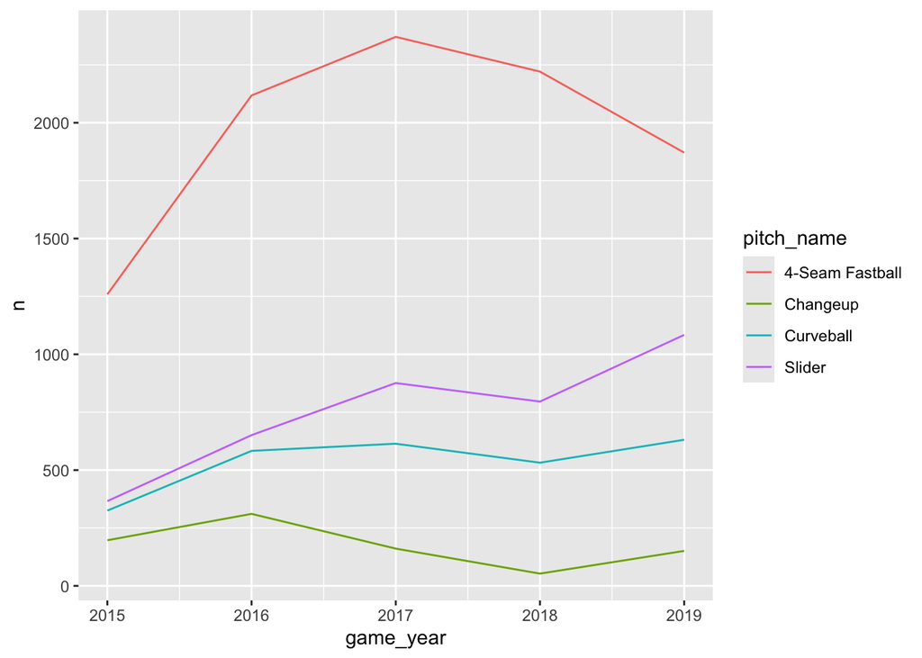

```r
verDataCounts = verDataAdjusted %>% group_by(pitch_name, game_year) %>% count()
verDataCounts %>% ggplot(aes(x=game_year, y=n, color=pitch_name)) + geom_line()
```

We can see that Verlander mostly pitches 4-seam fastballs for the entire 5 year period. From 2015 to 2017, the frequency with which he pitches these increases. The same pattern is true for sliders and curveballs. However, after 2016, the frequency with which he throws change-ups decreases drastically until 2018. From 2018 onwards, the amount of fastballs he pitches decreases harshly, while he throws more changeups, curveballs, and sliders.

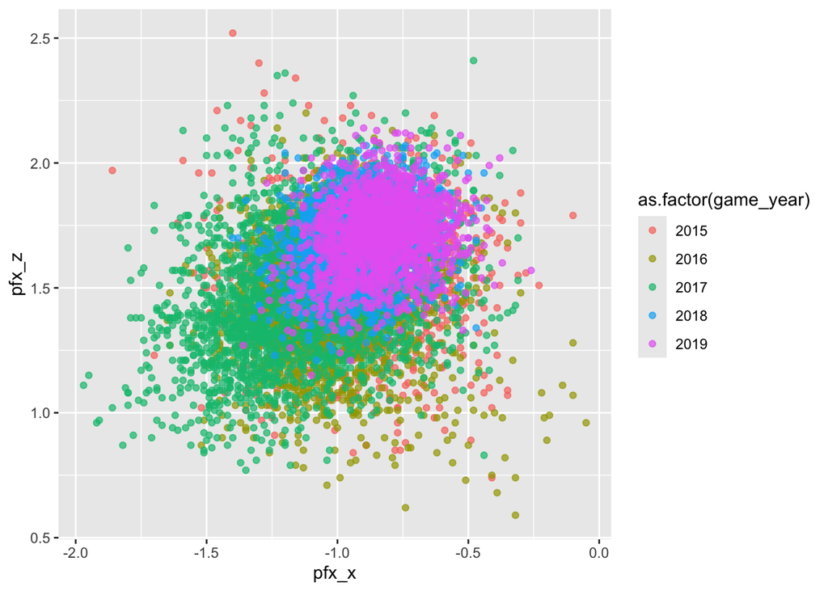

```r
fastballs = verDataAdjusted %>% filter(pitch_type=="FF")
fastballs %>% ggplot(aes(x=pfx_x, y=pfx_z, color=as.factor(game_year))) + geom_point(alpha=0.7)
```

From a glimpse at this graph, we can see that over time, Verlander’s pitches become much more condensed and accurate. His pitches in 2015 and 2016 tend to spread out the most in this scatter plot; however, his pitches in 2019 are all heavily concentrated in one area, with much less spread. This indicates an increase in control in his fastballs.

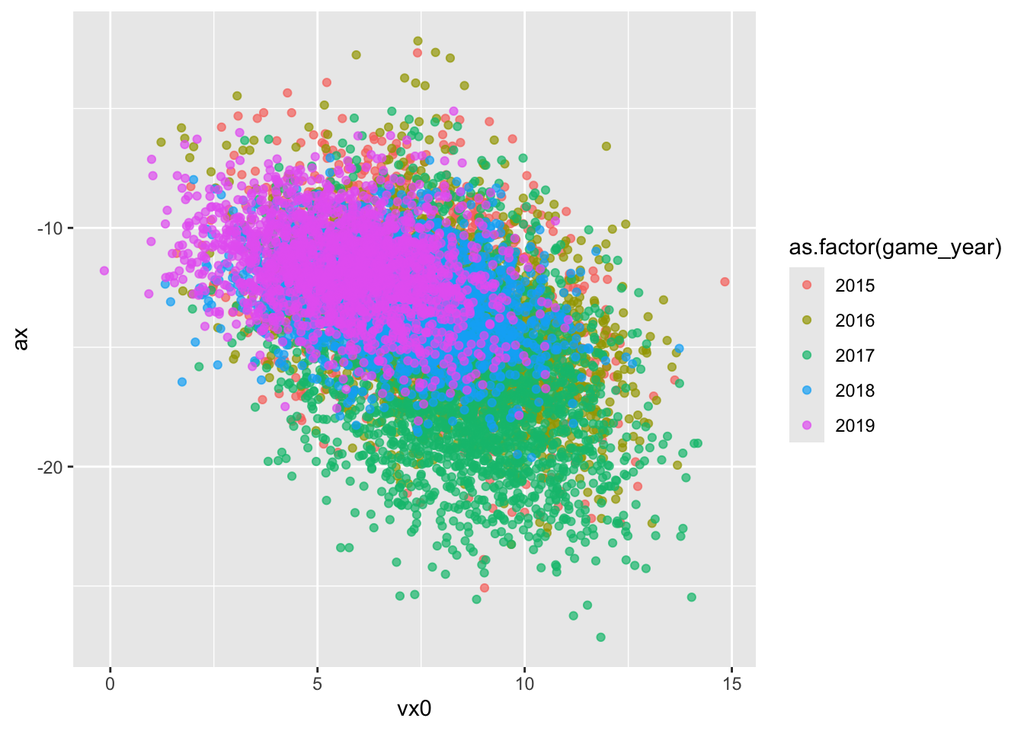

```r
#x velocity + acceleration
fastballs %>% ggplot(aes(x=vx0, y=ax, color=as.factor(game_year))) + geom_point(alpha=0.7)
```

In terms of x, we notice that over a five year period, Verlander’s x velocity got slower. However, the acceleration actually increased. For example, the center of his pitches in 2017 clustered around -20 ft/s/s, but in 2019, they were higher, with a center around -12 ft/s/s.

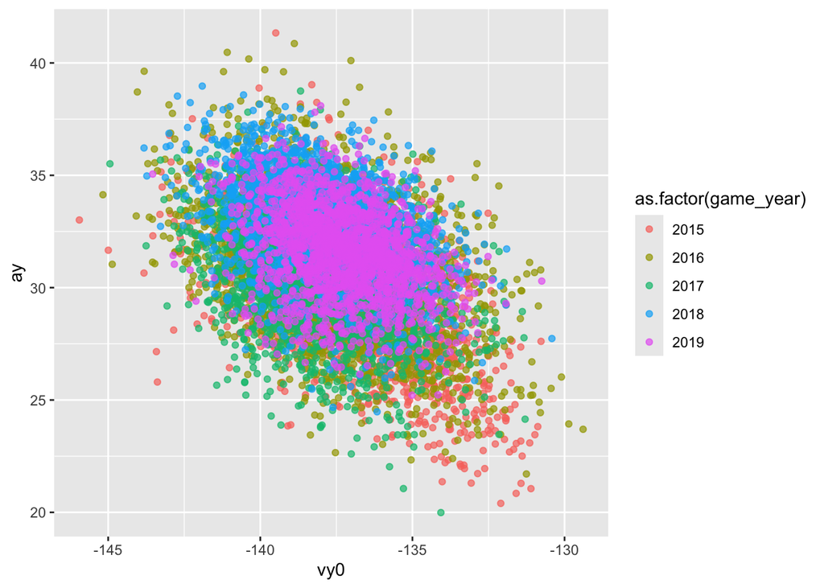

```r
# y velocity + acceleration
fastballs %>% ggplot(aes(x=vy0, y=ay, color=as.factor(game_year))) + geom_point(alpha=0.7)
```

Similarly, for y, we see that Verlander’s y velocity actually saw a tighter spread, which meant his velocity became more consistent, at around -137 ft/s/s. A similar story can be said of acceleration.

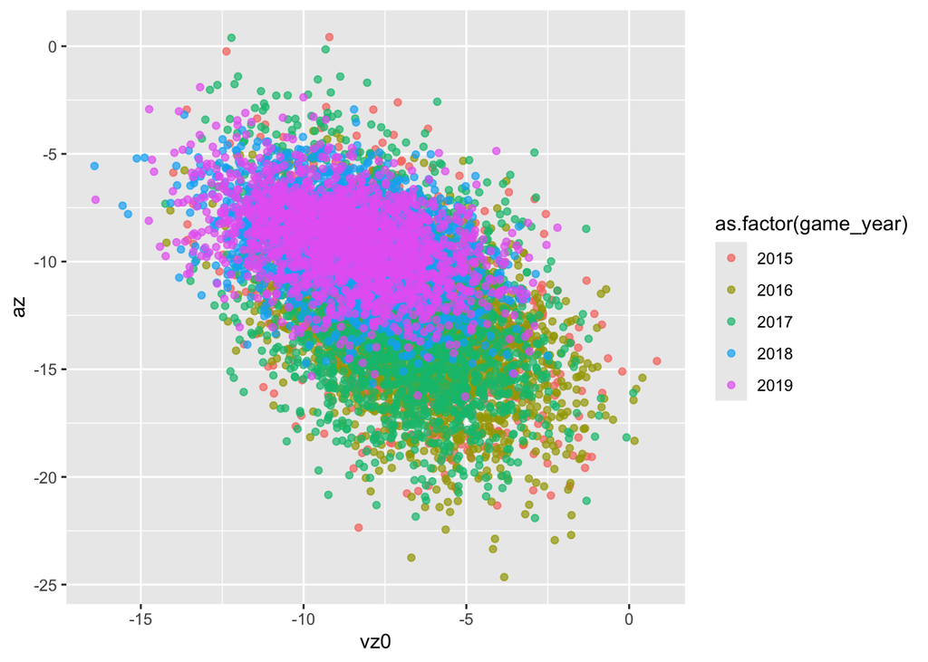

```r
fastballs %>% ggplot(aes(x=vz0, y=az, color=as.factor(game_year))) + geom_point(alpha=0.7)
```

In terms of z velocty, Verlander’s fastball pitch speed became slower but again more consistent. However, his z acceleration in 2019 was consistently higher and more condensed than his pitches in previous years, hovering at around -7 ft/s/s.

```r
library(vcd)
```

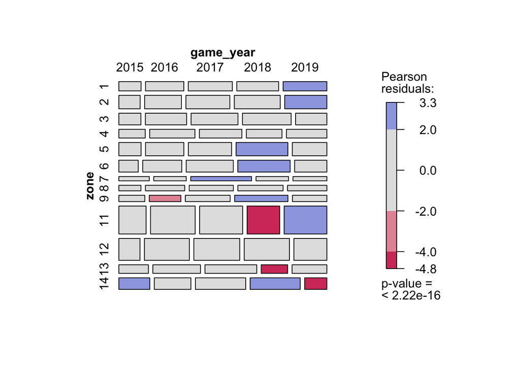

```r
zonesYear = xtabs(~zone+game_year, data=fastballs)

zonesYear %>% mosaic(shade=TRUE, direction="h")
```

Here, the colors of the mosaic plot indicate values of note. Specifically, we can see that in 2015, Verlander pitched in zone 14 more often than you would expect; however, in 2019, he pitched more frequently in zones 1 and 2 and much less frequently than in zone 14. This would indicate, for example, that Verlander’s fast ball pitches landed consistently higher in 2019 than he did in 2015.

```r
kruskal.test(vx0~game_year, data=fastballs)
```

```
##
##  Kruskal-Wallis rank sum test
##
## data:  vx0 by game_year
## Kruskal-Wallis chi-squared = 2027.4, df = 4, p-value < 2.2e-16
```

```r
kruskal.test(vy0~game_year, data=fastballs)
```

```
##
##  Kruskal-Wallis rank sum test
##
## data:  vy0 by game_year
## Kruskal-Wallis chi-squared = 552.66, df = 4, p-value < 2.2e-16
```

```r
kruskal.test(vz0~game_year, data=fastballs)
```

```
##
##  Kruskal-Wallis rank sum test
##
## data:  vz0 by game_year
## Kruskal-Wallis chi-squared = 1448.8, df = 4, p-value < 2.2e-16
```

```r
kruskal.test(ax~game_year, data=fastballs)
```

```
##
##  Kruskal-Wallis rank sum test
##
## data:  ax by game_year
## Kruskal-Wallis chi-squared = 2370.3, df = 4, p-value < 2.2e-16
```

```r
kruskal.test(ay~game_year, data=fastballs)
```

```
##
##  Kruskal-Wallis rank sum test
##
## data:  ay by game_year
## Kruskal-Wallis chi-squared = 1870.6, df = 4, p-value < 2.2e-16
```

```r
kruskal.test(az~game_year, data=fastballs)
```

```
##
##  Kruskal-Wallis rank sum test
##
## data:  az by game_year
## Kruskal-Wallis chi-squared = 3015.8, df = 4, p-value < 2.2e-16
```

```r
kruskal.test(pfx_x~game_year, data=fastballs)
```

```
##
##  Kruskal-Wallis rank sum test
##
## data:  pfx_x by game_year
## Kruskal-Wallis chi-squared = 1990.1, df = 4, p-value < 2.2e-16
```

```r
kruskal.test(pfx_z~game_year, data=fastballs)
```

```
##
##  Kruskal-Wallis rank sum test
##
## data:  pfx_z by game_year
## Kruskal-Wallis chi-squared = 2611, df = 4, p-value < 2.2e-16
```

```r
kruskal.test(zone~game_year, data=fastballs)
```

```
##
##  Kruskal-Wallis rank sum test
##
## data:  zone by game_year
## Kruskal-Wallis chi-squared = 28.395, df = 4, p-value = 1.037e-05
```

# Pairwise Texts

```r
pairwise.wilcox.test(fastballs$pfx_x, fastballs$game_year, p.adjust.method="bonferroni")
```

```
##
##  Pairwise comparisons using Wilcoxon rank sum test with continuity correction
##
## data:  fastballs$pfx_x and fastballs$game_year
##
##      2015   2016   2017   2018
## 2016 <2e-16 -      -      -
## 2017 <2e-16 <2e-16 -      -
## 2018 0.017  <2e-16 <2e-16 -
## 2019 <2e-16 <2e-16 <2e-16 <2e-16
##
## P value adjustment method: bonferroni
```

```r
pairwise.wilcox.test(fastballs$pfx_z, fastballs$game_year, p.adjust.method="bonferroni")
```

```
##
##  Pairwise comparisons using Wilcoxon rank sum test with continuity correction
##
## data:  fastballs$pfx_z and fastballs$game_year
##
##      2015    2016    2017    2018
## 2016 < 2e-16 -       -       -
## 2017 1.7e-10 0.21    -       -
## 2018 < 2e-16 < 2e-16 < 2e-16 -
## 2019 < 2e-16 < 2e-16 < 2e-16 1.7e-07
##
## P value adjustment method: bonferroni
```

```r
pairwise.wilcox.test(fastballs$vx0, fastballs$game_year, p.adjust.method="bonferroni")
```

```
##
##  Pairwise comparisons using Wilcoxon rank sum test with continuity correction
##
## data:  fastballs$vx0 and fastballs$game_year
##
##      2015    2016    2017    2018
## 2016 < 2e-16 -       -       -
## 2017 < 2e-16 1       -       -
## 2018 2.1e-11 < 2e-16 < 2e-16 -
## 2019 < 2e-16 < 2e-16 < 2e-16 < 2e-16
##
## P value adjustment method: bonferroni
```

```r
pairwise.wilcox.test(fastballs$vy0, fastballs$game_year, p.adjust.method="bonferroni")
```

```
##
##  Pairwise comparisons using Wilcoxon rank sum test with continuity correction
##
## data:  fastballs$vy0 and fastballs$game_year
##
##      2015    2016    2017    2018
## 2016 < 2e-16 -       -       -
## 2017 < 2e-16 2.5e-15 -       -
## 2018 < 2e-16 9.5e-06 0.00039 -
## 2019 < 2e-16 7.5e-06 < 2e-16 < 2e-16
##
## P value adjustment method: bonferroni
```

```r
pairwise.wilcox.test(fastballs$vz0, fastballs$game_year, p.adjust.method="bonferroni")
```

```
##
##  Pairwise comparisons using Wilcoxon rank sum test with continuity correction
##
## data:  fastballs$vz0 and fastballs$game_year
##
##      2015    2016    2017    2018
## 2016 5.2e-10 -       -       -
## 2017 0.58    < 2e-16 -       -
## 2018 < 2e-16 < 2e-16 < 2e-16 -
## 2019 < 2e-16 < 2e-16 < 2e-16 1.00
##
## P value adjustment method: bonferroni
```

```r
pairwise.wilcox.test(fastballs$ax, fastballs$game_year, p.adjust.method="bonferroni")
```

```
##
##  Pairwise comparisons using Wilcoxon rank sum test with continuity correction
##
## data:  fastballs$ax and fastballs$game_year
##
##      2015   2016   2017   2018
## 2016 <2e-16 -      -      -
## 2017 <2e-16 <2e-16 -      -
## 2018 0.22   <2e-16 <2e-16 -
## 2019 <2e-16 <2e-16 <2e-16 <2e-16
##
## P value adjustment method: bonferroni
```

```r
pairwise.wilcox.test(fastballs$ay, fastballs$game_year, p.adjust.method="bonferroni")
```

```
##
##  Pairwise comparisons using Wilcoxon rank sum test with continuity correction
##
## data:  fastballs$ay and fastballs$game_year
##
##      2015   2016   2017   2018
## 2016 <2e-16 -      -      -
## 2017 <2e-16 0.59   -      -
## 2018 <2e-16 <2e-16 <2e-16 -
## 2019 <2e-16 <2e-16 <2e-16 <2e-16
##
## P value adjustment method: bonferroni
```

```r
pairwise.wilcox.test(fastballs$az, fastballs$game_year, p.adjust.method="bonferroni")
```

```
##
##  Pairwise comparisons using Wilcoxon rank sum test with continuity correction
##
## data:  fastballs$az and fastballs$game_year
##
##      2015    2016    2017    2018
## 2016 3.1e-12 -       -       -
## 2017 1.00    2.3e-10 -       -
## 2018 < 2e-16 < 2e-16 < 2e-16 -
## 2019 < 2e-16 < 2e-16 < 2e-16 0.88
##
## P value adjustment method: bonferroni
```

```r
pairwise.wilcox.test(fastballs$zone, fastballs$game_year, p.adjust.method="bonferroni")
```

```
##
##  Pairwise comparisons using Wilcoxon rank sum test with continuity correction
##
## data:  fastballs$zone and fastballs$game_year
##
##      2015    2016    2017    2018
## 2016 1.00000 -       -       -
## 2017 1.00000 1.00000 -       -
## 2018 0.00529 0.05342 0.12510 -
## 2019 0.00025 0.00173 0.00707 1.00000
##
## P value adjustment method: bonferroni
```